# NBIS Report

14-Sep-2022

**NBIS ID:** SMS-6243  
**Report Version:** 1.0  
**Request by:** Ganesh Mohite (ganesh.mohite@liu.se)  
**Principal Investigator:** Per Hammarström (per.hammarstrom@liu.se)  
**Organisation:** Linköping University  
**NBIS Staff:** Juliana Assis (juliana.assis@nbis.se)

# 1 Setup

```r
## LIBRARIES
library("devtools")
library("dplyr")
library("ggplot2")
library("tidyr")
library("DECIPHER")
library("gplots")
library("gridExtra")
library("grid")
library("ggpubr")
library("reshape2")
library("reshape")
library("ggrepel")
library("ggh4x")
library("RColorBrewer")
library("tidyverse")
library("DESeq2") # Bioconductor
library('ggfortify')
library("AnnotationDbi")
library("EnsDb.Hsapiens.v86")
library("FactoMineR")
library("factoextra")
library("PCAtools")
library("Rqc")
library("gt")
library("clusterProfiler")
library("rnaseqGene")
```

# 2 Version

# 3 Support Request

# 4 Data

- Type of data 48 Samples: bulk RNASeq
- Data location /proj/snic2021-23-376/delivery05805
- Uppmax project ID

SNIC 2022/23-315 SNIC Small Storage  
SNIC 2022/22-598 SNIC Small Compute

- Reference data used Drosophila_melanogaster-Ensembl-BDGP6

# 5 Tools

nfcore-rnaseq

```r
data <- read.table("/Users/juliana/Documents/GitHub/SMS-6243-RNAseq/results/00-Reports/P.Hammarstrom_22_01_sample_info.txt", header=T, row.names=1, check.names=T, sep="\t")

head(data)
```

|  | User.ID | Mreads | X..Q30 |
| --- | --- | --- | --- |
| P24510_101 | Day 1 nSyb Abeta Females 1 | 69.64 | 93.40 |
| P24510_102 | Day 1 nSyb Abeta Females 2 | 68.28 | 94.00 |
| P24510_103 | Day 1 nSyb Abeta Females 3 | 69.87 | 94.07 |
| P24510_104 | Day 1 nSyb Abeta Males 1 | 72.89 | 93.77 |
| P24510_105 | Day 1 nSyb Abeta Males 2 | 61.05 | 93.48 |
| P24510_106 | Day 1 nSyb Abeta Males 3 | 59.79 | 93.31 |

# 6 Workflow

```
##
##  Shapiro-Wilk normality test
##
## data:  as.numeric(assay(exp[1, ]))
## W = 0.95502, p-value = 0.06825
```

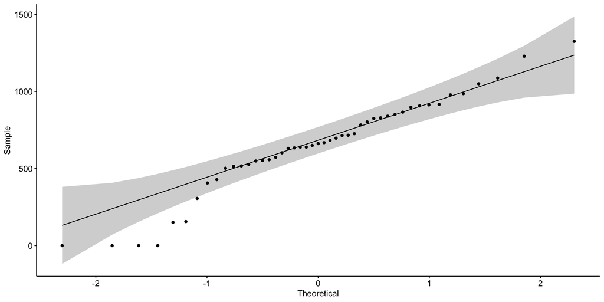

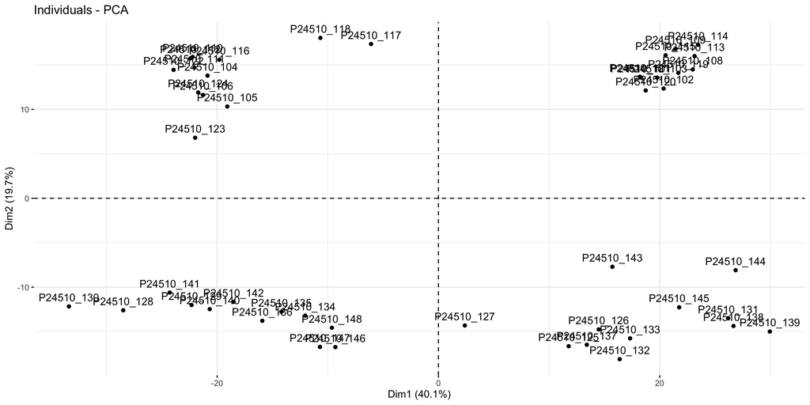

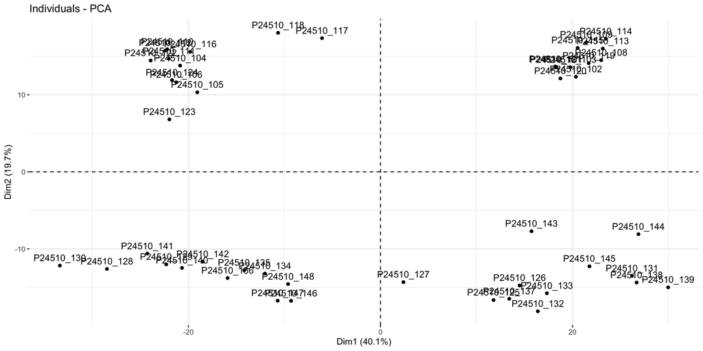

PCA plot of the first 2 principal components. Calculated using the 500 most variable genes.

```r
# PCA

#head(assay(exp, "counts"))
shapiro.test(as.numeric(assay(exp[1,])))
ggpubr::ggqqplot(as.numeric(assay(exp[1,])))

counts <- assay(exp, "counts")
colData <- (as.data.frame(exp@colData))

dds <- DESeqDataSetFromMatrix(countData = round(counts),
                              colData = colData,
                              design=~Replicates)

data_norm <- vst(assay(dds))
#dds <- DESeq(dds)
var_genes <- apply(data_norm, 1, var)

# Get the gene names for the top 500 most variable genes
select_var <- names(sort(var_genes, decreasing=TRUE))[1:500]
data_norm_var <- data_norm[select_var,]

# perform PCA
res.pca <- PCA(t(data_norm_var), scale.unit = FALSE, graph = FALSE)
# visualize
a <- fviz_pca_ind(res.pca)
cowplot::plot_grid(a)
a
```